# Revenue sources underlying statutory allocation links

IMF research project

2026-08-25

This notebook attaches the requested revenue classification to the analytical Census and expanded allocation-link tables. It then describes the composition of statutory allocation links by revenue class. The database is a **de jure** legal inventory; the counts and shares below do not measure revenue amounts, collections, transfers, disbursements, or expenditure execution.

# 1. Load and validate inputs

The two CSV files are read entirely as character data so their existing identifiers, legal text, missing cells, and row order can be preserved exactly.

```r
if (!all(file.exists(input_paths))) {
  stop(
    "Missing required input file(s): ",
    paste(input_paths[!file.exists(input_paths)], collapse = "; ")
  )
}

census_loaded <- read_all_character(input_paths[["census"]])
expanded_loaded <- read_all_character(input_paths[["expanded"]])

SSA_CENSUS_before <- remove_previous_classification(
  census_loaded,
  "SSA_CENSUS"
)
SSA_EARMARK_ALLOCATIONS_EXPANDED_before <- remove_previous_classification(
  expanded_loaded,
  "SSA_EARMARK_ALLOCATIONS_EXPANDED"
)

required_census_columns <- c(
  "country",
  "evidence_id",
  "instrument_id",
  "instrument_nature"
)
required_expanded_columns <- c(
  "country",
  "pair_id",
  "census_evidence_id",
  "census_instrument_id",
  "earmark_status"
)

missing_census_columns <- setdiff(
  required_census_columns,
  names(SSA_CENSUS_before)
)
missing_expanded_columns <- setdiff(
  required_expanded_columns,
  names(SSA_EARMARK_ALLOCATIONS_EXPANDED_before)
)

input_inventory <- tibble(
  dataset = c("SSA_CENSUS", "SSA_EARMARK_ALLOCATIONS_EXPANDED"),
  n_rows = c(
    nrow(SSA_CENSUS_before),
    nrow(SSA_EARMARK_ALLOCATIONS_EXPANDED_before)
  ),
  n_columns_before_classification = c(
    ncol(SSA_CENSUS_before),
    ncol(SSA_EARMARK_ALLOCATIONS_EXPANDED_before)
  ),
  missing_required_columns = c(
    if_else(
      length(missing_census_columns) == 0L,
      NA_character_,
      paste(missing_census_columns, collapse = "; ")
    ),
    if_else(
      length(missing_expanded_columns) == 0L,
      NA_character_,
      paste(missing_expanded_columns, collapse = "; ")
    )
  )
)

if (length(missing_census_columns) > 0L ||
    length(missing_expanded_columns) > 0L) {
  print(input_inventory)
  stop("One or more required input columns are missing.")
}
```

```r
display_table(input_inventory)
```

```
##
##
## |dataset                          | n_rows| n_columns_before_classification|missing_required_columns |
## |:--------------------------------|------:|-------------------------------:|:------------------------|
## |SSA_CENSUS                       |   2303|                              30|NA                       |
## |SSA_EARMARK_ALLOCATIONS_EXPANDED |   1453|                              32|NA                       |
```

# 2. Inspect and validate the revenue mapping

The workbook is expected to provide one exact mapping for each stored `instrument_nature`. Matching is exact; no fuzzy, translated, or manually inferred classifications are introduced.

```r
mapping_sheets <- excel_sheets(input_paths[["mapping"]])
if (length(mapping_sheets) != 1L) {
  stop(
    "The revenue mapping workbook must contain exactly one sheet; found: ",
    paste(mapping_sheets, collapse = "; ")
  )
}

revenue_mapping_loaded <- read_excel(
  input_paths[["mapping"]],
  sheet = mapping_sheets[[1]],
  col_types = "text",
  .name_repair = "minimal"
)

required_mapping_columns <- c(
  "instrument_nature",
  "revenue_class",
  "revenue_subclass"
)
missing_mapping_columns <- setdiff(
  required_mapping_columns,
  names(revenue_mapping_loaded)
)
additional_mapping_columns <- setdiff(
  names(revenue_mapping_loaded),
  required_mapping_columns
)

mapping_schema_audit <- tibble(
  workbook = "data/revenue_class_mapping.xlsx",
  sheet = mapping_sheets[[1]],
  n_rows = nrow(revenue_mapping_loaded),
  n_columns = ncol(revenue_mapping_loaded),
  missing_columns = if_else(
    length(missing_mapping_columns) == 0L,
    NA_character_,
    paste(missing_mapping_columns, collapse = "; ")
  ),
  additional_columns = if_else(
    length(additional_mapping_columns) == 0L,
    NA_character_,
    paste(additional_mapping_columns, collapse = "; ")
  )
)

if (length(missing_mapping_columns) > 0L) {
  print(mapping_schema_audit)
  stop("The mapping workbook is missing required columns.")
}

mapping_missing_fields <- revenue_mapping_loaded %>%
  transmute(
    instrument_nature,
    revenue_class,
    revenue_subclass,
    missing_instrument_nature = is_missing_text(instrument_nature),
    missing_revenue_class = is_missing_text(revenue_class),
    missing_revenue_subclass = is_missing_text(revenue_subclass)
  ) %>%
  filter(
    missing_instrument_nature |
      missing_revenue_class |
      missing_revenue_subclass
  )

mapping_duplicate_keys <- revenue_mapping_loaded %>%
  filter(!is_missing_text(instrument_nature)) %>%
  count(instrument_nature, name = "n_mapping_rows") %>%
  filter(n_mapping_rows > 1L) %>%
  arrange(desc(n_mapping_rows), instrument_nature)

mapping_conflicts <- revenue_mapping_loaded %>%
  filter(!is_missing_text(instrument_nature)) %>%
  distinct(instrument_nature, revenue_class, revenue_subclass) %>%
  count(instrument_nature, name = "n_distinct_mappings") %>%
  filter(n_distinct_mappings > 1L) %>%
  arrange(desc(n_distinct_mappings), instrument_nature)

if (any(is_missing_text(revenue_mapping_loaded$instrument_nature)) ||
    nrow(mapping_duplicate_keys) > 0L ||
    nrow(mapping_conflicts) > 0L) {
  print(mapping_missing_fields)
  print(mapping_duplicate_keys)
  print(mapping_conflicts)
  stop(
    "The mapping key is missing, duplicated, or ambiguous. ",
    "No derived file was changed."
  )
}

revenue_mapping <- revenue_mapping_loaded %>%
  select(all_of(required_mapping_columns))
```

```r
display_table(mapping_schema_audit)
```

```
##
##
## |workbook                        |sheet  | n_rows| n_columns|missing_columns |additional_columns |
## |:-------------------------------|:------|------:|---------:|:---------------|:------------------|
## |data/revenue_class_mapping.xlsx |Feuil1 |   1413|         3|NA              |NA                 |
```

```r
display_table(mapping_missing_fields)
```

```
## No rows to report.
```

```r
display_table(mapping_duplicate_keys)
```

```
## No rows to report.
```

```r
display_table(mapping_conflicts)
```

```
## No rows to report.
```

# 3. Append revenue classifications to Census

Unmatched `instrument_nature` values are reported and left unclassified. The original Census fields and row order remain unchanged.

```r
unmatched_instrument_nature <- SSA_CENSUS_before %>%
  anti_join(
    revenue_mapping %>% select(instrument_nature),
    by = "instrument_nature"
  ) %>%
  mutate(
    instrument_nature_display = if_else(
      is_missing_text(instrument_nature),
      "Missing",
      instrument_nature
    )
  ) %>%
  count(
    country,
    instrument_nature = instrument_nature_display,
    name = "n_census_rows"
  ) %>%
  arrange(country, instrument_nature)

instrument_nature_mapping_audit <- tibble(
  check = c(
    "Census rows",
    "distinct non-missing Census instrument_nature values",
    "matched Census rows",
    "unmatched Census rows",
    "unmatched distinct instrument_nature values"
  ),
  value = c(
    nrow(SSA_CENSUS_before),
    n_distinct(
      SSA_CENSUS_before$instrument_nature[
        !is_missing_text(SSA_CENSUS_before$instrument_nature)
      ]
    ),
    nrow(SSA_CENSUS_before) - sum(unmatched_instrument_nature$n_census_rows),
    sum(unmatched_instrument_nature$n_census_rows),
    nrow(unmatched_instrument_nature)
  )
)
```

```r
display_table(instrument_nature_mapping_audit)
```

```
##
##
## |check                                                | value|
## |:----------------------------------------------------|-----:|
## |Census rows                                          |  2303|
## |distinct non-missing Census instrument_nature values |  1413|
## |matched Census rows                                  |  2294|
## |unmatched Census rows                                |     9|
## |unmatched distinct instrument_nature values          |     9|
```

```r
display_table(unmatched_instrument_nature)
```

```
##
##
## |country |instrument_nature                                                                                                                                        | n_census_rows|
## |:-------|:--------------------------------------------------------------------------------------------------------------------------------------------------------|-------------:|
## |GIN     |contribution indirecte perçue sur les produits destinés à la consommation locale qui sont fabriqués ou importés en Guinée                                |             1|
## |GIN     |droit progressif (ligne directe et entre époux) ou proportionnel (entre non-parents)                                                                     |             1|
## |GIN     |general consumption tax on supplies of goods, supplies of services and imports                                                                           |             1|
## |GIN     |impôt minimum annuel assis sur le chiffre d’affaires                                                                                                     |             1|
## |GIN     |impôt synthétique annuel sur la propriété foncière et les revenus fonciers                                                                               |             1|
## |GIN     |prélèvement forfaitaire perçu à l’importation et retenu à la source sur achats et commissions                                                            |             1|
## |GIN     |taxe sur les conventions ou contrats d'assurances et de rentes viagères conclus avec une société d'assurances ou tout autre assureur guinéen ou étranger |             1|
## |GIN     |taxe sur les opérations bancaires et financières réalisées par les établissements de crédit et bureaux de change réglementés établis en Guinée           |             1|
## |GIN     |taxe synthétique annuelle assise sur le chiffre d’affaires                                                                                               |             1|
```

```r
SSA_CENSUS <- SSA_CENSUS_before %>%
  mutate(.original_row_order = row_number()) %>%
  left_join(
    revenue_mapping,
    by = "instrument_nature",
    relationship = "many-to-one"
  ) %>%
  arrange(.original_row_order) %>%
  select(
    all_of(names(SSA_CENSUS_before)),
    all_of(requested_classification_columns)
  )

census_prewrite_checks <- make_preservation_checks(
  "SSA_CENSUS",
  SSA_CENSUS_before,
  SSA_CENSUS
)

if (!all(census_prewrite_checks$passed)) {
  print(census_prewrite_checks %>% filter(!passed))
  stop("Census preservation checks failed; no output was written.")
}
```

# 4. Append Census classifications to expanded allocation links

The join uses `country + census_evidence_id = evidence_id`. A matched Census row must also carry the same instrument identifier as the expanded link.

```r
census_lookup_key_audit <- SSA_CENSUS %>%
  summarise(
    n_rows = n(),
    missing_country = sum(is_missing_text(country)),
    missing_evidence_id = sum(is_missing_text(evidence_id)),
    n_duplicate_country_evidence_keys = nrow(
      SSA_CENSUS %>%
        count(country, evidence_id, name = "n_rows") %>%
        filter(n_rows > 1L)
    )
  )

duplicate_census_lookup_keys <- SSA_CENSUS %>%
  count(country, evidence_id, name = "n_rows") %>%
  filter(n_rows > 1L) %>%
  arrange(desc(n_rows), country, evidence_id)

if (census_lookup_key_audit$missing_country > 0L ||
    census_lookup_key_audit$missing_evidence_id > 0L ||
    nrow(duplicate_census_lookup_keys) > 0L) {
  print(census_lookup_key_audit)
  print(duplicate_census_lookup_keys)
  stop(
    "The Census join key is incomplete or ambiguous. ",
    "No expanded file was changed."
  )
}
```

```r
census_classification_lookup <- SSA_CENSUS %>%
  transmute(
    country,
    census_evidence_id = evidence_id,
    census_instrument_id_from_census = instrument_id,
    revenue_class,
    revenue_subclass,
    census_match_found = TRUE
  )

expanded_joined <- SSA_EARMARK_ALLOCATIONS_EXPANDED_before %>%
  mutate(.original_row_order = row_number()) %>%
  left_join(
    census_classification_lookup,
    by = c("country", "census_evidence_id"),
    relationship = "many-to-one"
  ) %>%
  arrange(.original_row_order)

instrument_link_mismatches <- expanded_joined %>%
  filter(
    !is.na(census_match_found),
    census_instrument_id != census_instrument_id_from_census
  ) %>%
  select(
    country,
    pair_id,
    census_evidence_id,
    expanded_census_instrument_id = census_instrument_id,
    census_instrument_id = census_instrument_id_from_census
  )

if (nrow(instrument_link_mismatches) > 0L) {
  print(instrument_link_mismatches)
  stop(
    "Matched Census evidence IDs disagree with expanded census instrument IDs. ",
    "No output was written."
  )
}

unmatched_census_joins <- expanded_joined %>%
  filter(is.na(census_match_found)) %>%
  count(country, name = "n_unmatched_expanded_rows") %>%
  left_join(
    expanded_joined %>%
      filter(is.na(census_match_found)) %>%
      distinct(country, census_evidence_id) %>%
      count(country, name = "n_distinct_unmatched_census_evidence_ids"),
    by = "country"
  ) %>%
  arrange(desc(n_unmatched_expanded_rows), country)

join_audit <- tibble(
  check = c(
    "expanded rows before join",
    "expanded rows after join",
    "matched Census rows",
    "unmatched Census joins",
    "ambiguous Census joins",
    "matched instrument-ID disagreements"
  ),
  value = c(
    nrow(SSA_EARMARK_ALLOCATIONS_EXPANDED_before),
    nrow(expanded_joined),
    sum(!is.na(expanded_joined$census_match_found)),
    sum(is.na(expanded_joined$census_match_found)),
    nrow(duplicate_census_lookup_keys),
    nrow(instrument_link_mismatches)
  )
)

SSA_EARMARK_ALLOCATIONS_EXPANDED <- expanded_joined %>%
  select(
    all_of(names(SSA_EARMARK_ALLOCATIONS_EXPANDED_before)),
    all_of(requested_classification_columns)
  )

expanded_prewrite_checks <- make_preservation_checks(
  "SSA_EARMARK_ALLOCATIONS_EXPANDED",
  SSA_EARMARK_ALLOCATIONS_EXPANDED_before,
  SSA_EARMARK_ALLOCATIONS_EXPANDED
)

if (!all(expanded_prewrite_checks$passed)) {
  print(expanded_prewrite_checks %>% filter(!passed))
  stop("Expanded-table preservation checks failed; no output was written.")
}
```

```r
display_table(census_lookup_key_audit)
```

```
##
##
## | n_rows| missing_country| missing_evidence_id| n_duplicate_country_evidence_keys|
## |------:|---------------:|-------------------:|---------------------------------:|
## |   2303|               0|                   0|                                 0|
```

```r
display_table(duplicate_census_lookup_keys)
```

```
## No rows to report.
```

```r
display_table(join_audit)
```

```
##
##
## |check                               | value|
## |:-----------------------------------|-----:|
## |expanded rows before join           |  1453|
## |expanded rows after join            |  1453|
## |matched Census rows                 |  1327|
## |unmatched Census joins              |   126|
## |ambiguous Census joins              |     0|
## |matched instrument-ID disagreements |     0|
```

```r
display_table(unmatched_census_joins)
```

```
##
##
## |country | n_unmatched_expanded_rows| n_distinct_unmatched_census_evidence_ids|
## |:-------|-------------------------:|----------------------------------------:|
## |CIV     |                        81|                                       39|
## |COG     |                        19|                                        7|
## |CAF     |                        12|                                        4|
## |COD     |                         4|                                        2|
## |BEN     |                         2|                                        2|
## |CMR     |                         2|                                        1|
## |GHA     |                         2|                                        2|
## |MLI     |                         2|                                        2|
## |GAB     |                         1|                                        1|
## |TCD     |                         1|                                        1|
```

```r
display_table(instrument_link_mismatches)
```

```
## No rows to report.
```

# 5. Verify the atomic allocation-link unit

One atomic allocation link is one distinct `country + pair_id + census_instrument_id` combination. Counts are constructed only after confirming this key is complete and unique.

```r
atomic_key_missing_rows <- SSA_EARMARK_ALLOCATIONS_EXPANDED %>%
  filter(
    is_missing_text(country) |
      is_missing_text(pair_id) |
      is_missing_text(census_instrument_id)
  ) %>%
  select(
    country,
    pair_id,
    census_instrument_id,
    census_evidence_id
  )

duplicate_atomic_link_keys <- SSA_EARMARK_ALLOCATIONS_EXPANDED %>%
  count(
    country,
    pair_id,
    census_instrument_id,
    name = "n_rows"
  ) %>%
  filter(n_rows > 1L) %>%
  arrange(desc(n_rows), country, pair_id, census_instrument_id)

atomic_key_audit <- tibble(
  check = c(
    "expanded rows",
    "distinct complete atomic-link keys",
    "rows with an incomplete atomic-link key",
    "duplicate atomic-link keys",
    "duplicate-row excess over the atomic key"
  ),
  value = c(
    nrow(SSA_EARMARK_ALLOCATIONS_EXPANDED),
    nrow(
      SSA_EARMARK_ALLOCATIONS_EXPANDED %>%
        filter(
          !is_missing_text(country),
          !is_missing_text(pair_id),
          !is_missing_text(census_instrument_id)
        ) %>%
        distinct(country, pair_id, census_instrument_id)
    ),
    nrow(atomic_key_missing_rows),
    nrow(duplicate_atomic_link_keys),
    sum(pmax(duplicate_atomic_link_keys$n_rows - 1L, 0L))
  )
)

if (nrow(atomic_key_missing_rows) > 0L ||
    nrow(duplicate_atomic_link_keys) > 0L) {
  print(atomic_key_audit)
  print(atomic_key_missing_rows)
  print(duplicate_atomic_link_keys)
  stop(
    "The atomic allocation-link key is incomplete or duplicated. ",
    "No summary or output was created."
  )
}

atomic_links_all <- SSA_EARMARK_ALLOCATIONS_EXPANDED %>%
  distinct(country, pair_id, census_instrument_id, .keep_all = TRUE) %>%
  mutate(
    revenue_class_display = if_else(
      is_missing_text(revenue_class),
      "Missing",
      revenue_class
    )
  )

atomic_links_earmarked <- atomic_links_all %>%
  filter(earmark_status %in% partial_exclusive_statuses)

earmark_status_filter_audit <- tibble(
  sample = c(
    "All statutory allocations",
    "Partial and exclusive earmarks"
  ),
  n_atomic_links = c(
    nrow(atomic_links_all),
    nrow(atomic_links_earmarked)
  ),
  statuses_present = c(
    paste(
      sort(unique(atomic_links_all$earmark_status)),
      collapse = "; "
    ),
    paste(
      sort(unique(atomic_links_earmarked$earmark_status)),
      collapse = "; "
    )
  )
)
```

```r
display_table(atomic_key_audit)
```

```
##
##
## |check                                    | value|
## |:----------------------------------------|-----:|
## |expanded rows                            |  1453|
## |distinct complete atomic-link keys       |  1453|
## |rows with an incomplete atomic-link key  |     0|
## |duplicate atomic-link keys               |     0|
## |duplicate-row excess over the atomic key |     0|
```

```r
display_table(atomic_key_missing_rows)
```

```
## No rows to report.
```

```r
display_table(duplicate_atomic_link_keys)
```

```
## No rows to report.
```

```r
display_table(earmark_status_filter_audit)
```

```
##
##
## |sample                         | n_atomic_links|statuses_present                                                              |
## |:------------------------------|--------------:|:-----------------------------------------------------------------------------|
## |All statutory allocations      |           1453|assigned_unrestricted; cost_recovery_only; exclusive_earmark; partial_earmark |
## |Partial and exclusive earmarks |            810|exclusive_earmark; partial_earmark                                            |
```

# 6. Revenue-class summary

Missing Census matches and unmatched `instrument_nature` values remain visible as `Missing`. No link is removed from either denominator.

```r
total_links_all <- nrow(atomic_links_all)
total_links_earmarked <- nrow(atomic_links_earmarked)

if (total_links_all == 0L || total_links_earmarked == 0L) {
  stop("Both the full and filtered samples must contain at least one link.")
}

revenue_class_counts_all <- atomic_links_all %>%
  count(revenue_class = revenue_class_display, name = "n_links_all")

revenue_class_counts_earmarked <- atomic_links_earmarked %>%
  count(
    revenue_class = revenue_class_display,
    name = "n_links_earmarked"
  )

revenue_class_summary <- full_join(
  revenue_class_counts_all,
  revenue_class_counts_earmarked,
  by = "revenue_class"
) %>%
  mutate(
    n_links_all = replace_na(n_links_all, 0L),
    n_links_earmarked = replace_na(n_links_earmarked, 0L),
    share_links_all = n_links_all / total_links_all,
    share_links_earmarked = n_links_earmarked / total_links_earmarked
  ) %>%
  select(
    revenue_class,
    n_links_all,
    share_links_all,
    n_links_earmarked,
    share_links_earmarked
  ) %>%
  arrange(desc(n_links_all), revenue_class)

share_and_total_checks <- tibble(
  sample = c(
    "All statutory allocations",
    "Partial and exclusive earmarks"
  ),
  total_atomic_links = c(total_links_all, total_links_earmarked),
  sum_class_link_counts = c(
    sum(revenue_class_summary$n_links_all),
    sum(revenue_class_summary$n_links_earmarked)
  ),
  sum_class_shares = c(
    sum(revenue_class_summary$share_links_all),
    sum(revenue_class_summary$share_links_earmarked)
  ),
  passed = c(
    sum(revenue_class_summary$n_links_all) == total_links_all &&
      isTRUE(all.equal(
        sum(revenue_class_summary$share_links_all),
        1,
        tolerance = 1e-12
      )),
    sum(revenue_class_summary$n_links_earmarked) == total_links_earmarked &&
      isTRUE(all.equal(
        sum(revenue_class_summary$share_links_earmarked),
        1,
        tolerance = 1e-12
      ))
  )
)

if (!all(share_and_total_checks$passed)) {
  print(share_and_total_checks)
  stop("Revenue-class counts or shares do not reconcile to their sample total.")
}
```

```r
display_table(revenue_class_summary)
```

```
##
##
## |revenue_class                              | n_links_all| share_links_all| n_links_earmarked| share_links_earmarked|
## |:------------------------------------------|-----------:|---------------:|-----------------:|---------------------:|
## |sector_specific_and_business_levies        |         343|        0.236063|               187|              0.230864|
## |administrative_regulatory_and_user_charges |         266|        0.183070|               144|              0.177778|
## |natural_resources_and_extractives          |         194|        0.133517|                95|              0.117284|
## |registration_stamp_and_legal_duties        |         141|        0.097041|                18|              0.022222|
## |Missing                                    |         140|        0.096352|               116|              0.143210|
## |environmental_and_pollution                |          90|        0.061941|                84|              0.103704|
## |excises_and_specific_consumption           |          65|        0.044735|                45|              0.055556|
## |property_and_wealth                        |          64|        0.044047|                25|              0.030864|
## |income_profits_and_capital_gains           |          52|        0.035788|                25|              0.030864|
## |payroll_and_social_contributions           |          29|        0.019959|                29|              0.035802|
## |general_consumption_and_turnover           |          21|        0.014453|                15|              0.018519|
## |international_trade_and_customs            |          16|        0.011012|                14|              0.017284|
## |unclassified_review                        |          16|        0.011012|                 5|              0.006173|
## |penalties_interest_and_other_receipts      |          11|        0.007571|                 3|              0.003704|
## |financial_and_transaction_taxes            |           5|        0.003441|                 5|              0.006173|
```

```r
display_table(share_and_total_checks)
```

```
##
##
## |sample                         | total_atomic_links| sum_class_link_counts| sum_class_shares|passed |
## |:------------------------------|------------------:|---------------------:|----------------:|:------|
## |All statutory allocations      |               1453|                  1453|                1|TRUE   |
## |Partial and exclusive earmarks |                810|                   810|                1|TRUE   |
```

# 7. Exact plot data

The two CSV tables below contain exactly the rows and values displayed in their matching figures. The readable labels are derived only for presentation; the stored `revenue_class` codes remain unchanged.

```r
make_revenue_class_label <- function(values) {
  values %>%
    str_replace_all("_", " ") %>%
    str_to_sentence() %>%
    str_wrap(width = 34)
}

revenue_class_all_plot_data <- revenue_class_summary %>%
  transmute(
    revenue_class,
    revenue_class_label = make_revenue_class_label(revenue_class),
    n_links_all,
    share_links_all
  ) %>%
  arrange(desc(share_links_all), revenue_class)

revenue_class_earmarked_plot_data <- revenue_class_summary %>%
  transmute(
    revenue_class,
    revenue_class_label = make_revenue_class_label(revenue_class),
    n_links_earmarked,
    share_links_earmarked
  ) %>%
  arrange(desc(share_links_earmarked), revenue_class)
```

```r
display_table(revenue_class_all_plot_data)
```

```
##
##
## |revenue_class                              |revenue_class_label                       | n_links_all| share_links_all|
## |:------------------------------------------|:-----------------------------------------|-----------:|---------------:|
## |sector_specific_and_business_levies        |Sector specific and business
## levies        |         343|        0.236063|
## |administrative_regulatory_and_user_charges |Administrative regulatory and user
## charges |         266|        0.183070|
## |natural_resources_and_extractives          |Natural resources and extractives         |         194|        0.133517|
## |registration_stamp_and_legal_duties        |Registration stamp and legal
## duties        |         141|        0.097041|
## |Missing                                    |Missing                                   |         140|        0.096352|
## |environmental_and_pollution                |Environmental and pollution               |          90|        0.061941|
## |excises_and_specific_consumption           |Excises and specific consumption          |          65|        0.044735|
## |property_and_wealth                        |Property and wealth                       |          64|        0.044047|
## |income_profits_and_capital_gains           |Income profits and capital gains          |          52|        0.035788|
## |payroll_and_social_contributions           |Payroll and social contributions          |          29|        0.019959|
## |general_consumption_and_turnover           |General consumption and turnover          |          21|        0.014453|
## |international_trade_and_customs            |International trade and customs           |          16|        0.011012|
## |unclassified_review                        |Unclassified review                       |          16|        0.011012|
## |penalties_interest_and_other_receipts      |Penalties interest and other
## receipts      |          11|        0.007571|
## |financial_and_transaction_taxes            |Financial and transaction taxes           |           5|        0.003441|
```

```r
display_table(revenue_class_earmarked_plot_data)
```

```
##
##
## |revenue_class                              |revenue_class_label                       | n_links_earmarked| share_links_earmarked|
## |:------------------------------------------|:-----------------------------------------|-----------------:|---------------------:|
## |sector_specific_and_business_levies        |Sector specific and business
## levies        |               187|              0.230864|
## |administrative_regulatory_and_user_charges |Administrative regulatory and user
## charges |               144|              0.177778|
## |Missing                                    |Missing                                   |               116|              0.143210|
## |natural_resources_and_extractives          |Natural resources and extractives         |                95|              0.117284|
## |environmental_and_pollution                |Environmental and pollution               |                84|              0.103704|
## |excises_and_specific_consumption           |Excises and specific consumption          |                45|              0.055556|
## |payroll_and_social_contributions           |Payroll and social contributions          |                29|              0.035802|
## |income_profits_and_capital_gains           |Income profits and capital gains          |                25|              0.030864|
## |property_and_wealth                        |Property and wealth                       |                25|              0.030864|
## |registration_stamp_and_legal_duties        |Registration stamp and legal
## duties        |                18|              0.022222|
## |general_consumption_and_turnover           |General consumption and turnover          |                15|              0.018519|
## |international_trade_and_customs            |International trade and customs           |                14|              0.017284|
## |financial_and_transaction_taxes            |Financial and transaction taxes           |                 5|              0.006173|
## |unclassified_review                        |Unclassified review                       |                 5|              0.006173|
## |penalties_interest_and_other_receipts      |Penalties interest and other
## receipts      |                 3|              0.003704|
```

# 8. All statutory allocations

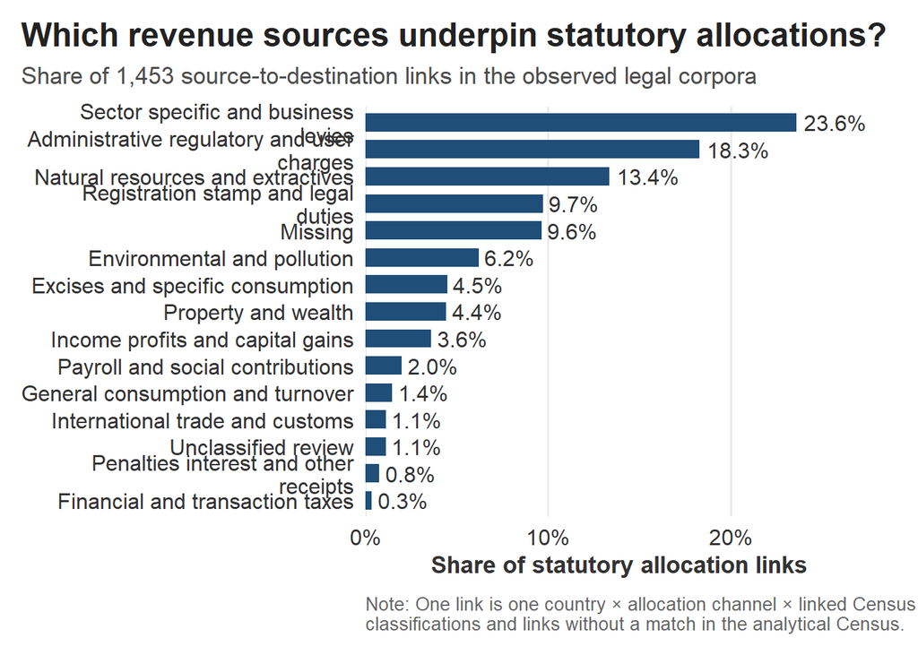

```r
all_plot_frame <- revenue_class_all_plot_data %>%
  mutate(
    revenue_class_label = factor(
      revenue_class_label,
      levels = rev(revenue_class_label)
    )
  )

revenue_class_all_plot <- ggplot(
  all_plot_frame,
  aes(x = share_links_all, y = revenue_class_label)
) +
  geom_col(width = 0.68, fill = main_blue) +
  geom_text(
    aes(label = label_percent(accuracy = 0.1)(share_links_all)),
    hjust = -0.12,
    colour = "#333333",
    size = 4.2
  ) +
  scale_x_continuous(
    labels = label_percent(accuracy = 1),
    limits = c(0, NA),
    expand = expansion(mult = c(0, 0.18))
  ) +
  labs(
    title = "Which revenue sources underpin statutory allocations?",
    subtitle = paste0(
      "Share of ", comma(total_links_all),
      " source-to-destination links in the observed legal corpora"
    ),
    x = "Share of statutory allocation links",
    y = NULL,
    caption = str_wrap(
      paste0(
        "Note: One link is one country × allocation channel × linked Census ",
        "instrument. Missing includes unmatched classifications and links ",
        "without a match in the analytical Census."
      ),
      width = 105
    )
  ) +
  theme_revenue_class
```

# 9. Partial and exclusive earmarks

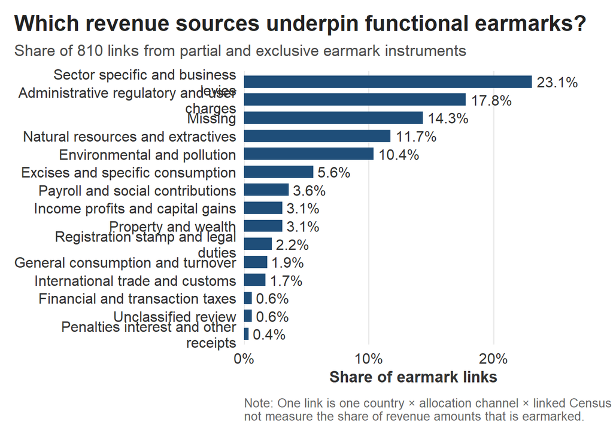

```r
earmarked_plot_frame <- revenue_class_earmarked_plot_data %>%
  mutate(
    revenue_class_label = factor(
      revenue_class_label,
      levels = rev(revenue_class_label)
    )
  )

revenue_class_earmarked_plot <- ggplot(
  earmarked_plot_frame,
  aes(x = share_links_earmarked, y = revenue_class_label)
) +
  geom_col(width = 0.68, fill = main_blue) +
  geom_text(
    aes(label = label_percent(accuracy = 0.1)(share_links_earmarked)),
    hjust = -0.12,
    colour = "#333333",
    size = 4.2
  ) +
  scale_x_continuous(
    labels = label_percent(accuracy = 1),
    limits = c(0, NA),
    expand = expansion(mult = c(0, 0.18))
  ) +
  labs(
    title = "Which revenue sources underpin functional earmarks?",
    subtitle = paste0(
      "Share of ", comma(total_links_earmarked),
      " links from partial and exclusive earmark instruments"
    ),
    x = "Share of earmark links",
    y = NULL,
    caption = str_wrap(
      paste0(
        "Note: One link is one country × allocation channel × linked Census ",
        "instrument. The classification does not measure the share of ",
        "revenue amounts that is earmarked."
      ),
      width = 105
    )
  ) +
  theme_revenue_class
```

# 10. Stage, verify, and commit all outputs

All candidate files are written to temporary paths and checked before any final path is overwritten. Existing final files are backed up and restored if a commit or final read-back check fails.

```r
stage_dir <- tempfile(pattern = "08_revenue_class_stage_")
dir.create(stage_dir, recursive = TRUE, showWarnings = FALSE)

stage_paths <- file.path(stage_dir, basename(output_paths))
names(stage_paths) <- names(output_paths)

write_csv(SSA_CENSUS, stage_paths[["census"]], na = "")
write_csv(
  SSA_EARMARK_ALLOCATIONS_EXPANDED,
  stage_paths[["expanded"]],
  na = ""
)
write_csv(
  revenue_class_summary,
  stage_paths[["summary"]],
  na = ""
)
write_csv(
  revenue_class_all_plot_data,
  stage_paths[["all_plot_data"]],
  na = ""
)
write_csv(
  revenue_class_earmarked_plot_data,
  stage_paths[["earmarked_plot_data"]],
  na = ""
)

ggsave(
  filename = stage_paths[["all_figure"]],
  plot = revenue_class_all_plot,
  width = 10.5,
  height = 7.2,
  units = "in",
  dpi = 300,
  bg = "white"
)
ggsave(
  filename = stage_paths[["earmarked_figure"]],
  plot = revenue_class_earmarked_plot,
  width = 10.5,
  height = 7.2,
  units = "in",
  dpi = 300,
  bg = "white"
)

staged_census <- read_all_character(stage_paths[["census"]])
staged_expanded <- read_all_character(stage_paths[["expanded"]])

staged_preservation_checks <- bind_rows(
  make_preservation_checks(
    "SSA_CENSUS",
    SSA_CENSUS_before,
    staged_census
  ),
  make_preservation_checks(
    "SSA_EARMARK_ALLOCATIONS_EXPANDED",
    SSA_EARMARK_ALLOCATIONS_EXPANDED_before,
    staged_expanded
  )
)

read_analysis_csv <- function(path) {
  read_csv(path, show_col_types = FALSE, progress = FALSE)
}

same_table_values <- function(saved, expected) {
  identical(names(saved), names(expected)) &&
    nrow(saved) == nrow(expected) &&
    isTRUE(all.equal(
      as.data.frame(saved),
      as.data.frame(expected),
      check.attributes = FALSE,
      tolerance = 1e-12
    ))
}

staged_analysis_checks <- tibble(
  output = c(
    "08_revenue_class_summary.csv",
    "08_revenue_class_all.csv",
    "08_revenue_class_partial_exclusive.csv",
    "08_revenue_class_all.png",
    "08_revenue_class_partial_exclusive.png"
  ),
  passed = c(
    same_table_values(
      read_analysis_csv(stage_paths[["summary"]]),
      revenue_class_summary
    ),
    same_table_values(
      read_analysis_csv(stage_paths[["all_plot_data"]]),
      revenue_class_all_plot_data
    ),
    same_table_values(
      read_analysis_csv(stage_paths[["earmarked_plot_data"]]),
      revenue_class_earmarked_plot_data
    ),
    file.info(stage_paths[["all_figure"]])$size > 10000,
    file.info(stage_paths[["earmarked_figure"]])$size > 10000
  )
)

if (!all(staged_preservation_checks$passed) ||
    !all(staged_analysis_checks$passed)) {
  print(staged_preservation_checks %>% filter(!passed))
  print(staged_analysis_checks %>% filter(!passed))
  stop("Staged output checks failed; no final path was overwritten.")
}
```

```r
commit_output_bundle <- function(stage_paths, output_paths) {
  existed_before <- file.exists(output_paths)
  backup_dir <- tempfile(pattern = "08_revenue_class_backup_")
  dir.create(backup_dir, recursive = TRUE, showWarnings = FALSE)
  backup_paths <- file.path(backup_dir, basename(output_paths))
  names(backup_paths) <- names(output_paths)
  committed <- FALSE

  on.exit({
    if (!committed) {
      for (name in names(output_paths)) {
        if (existed_before[[name]] && file.exists(backup_paths[[name]])) {
          file.copy(
            backup_paths[[name]],
            output_paths[[name]],
            overwrite = TRUE
          )
        } else if (!existed_before[[name]] &&
                   file.exists(output_paths[[name]])) {
          file.remove(output_paths[[name]])
        }
      }
    }
    unlink(stage_dir, recursive = TRUE, force = TRUE)
    unlink(backup_dir, recursive = TRUE, force = TRUE)
  }, add = TRUE)

  for (name in names(output_paths)[existed_before]) {
    if (!file.copy(
      output_paths[[name]],
      backup_paths[[name]],
      overwrite = FALSE
    )) {
      stop("Could not create a rollback copy for ", name, ".")
    }
  }

  commit_ok <- vapply(
    names(output_paths),
    function(name) file.copy(
      stage_paths[[name]],
      output_paths[[name]],
      overwrite = TRUE
    ),
    logical(1)
  )
  if (!all(commit_ok)) {
    stop("Could not commit every requested output file.")
  }

  final_census <- read_all_character(output_paths[["census"]])
  final_expanded <- read_all_character(output_paths[["expanded"]])

  final_preservation_checks <- bind_rows(
    make_preservation_checks(
      "SSA_CENSUS",
      SSA_CENSUS_before,
      final_census
    ),
    make_preservation_checks(
      "SSA_EARMARK_ALLOCATIONS_EXPANDED",
      SSA_EARMARK_ALLOCATIONS_EXPANDED_before,
      final_expanded
    )
  )

  final_analysis_checks <- tibble(
    output = c(
      "08_revenue_class_summary.csv",
      "08_revenue_class_all.csv",
      "08_revenue_class_partial_exclusive.csv",
      "08_revenue_class_all.png",
      "08_revenue_class_partial_exclusive.png"
    ),
    passed = c(
      same_table_values(
        read_analysis_csv(output_paths[["summary"]]),
        revenue_class_summary
      ),
      same_table_values(
        read_analysis_csv(output_paths[["all_plot_data"]]),
        revenue_class_all_plot_data
      ),
      same_table_values(
        read_analysis_csv(output_paths[["earmarked_plot_data"]]),
        revenue_class_earmarked_plot_data
      ),
      file.info(output_paths[["all_figure"]])$size > 10000,
      file.info(output_paths[["earmarked_figure"]])$size > 10000
    )
  )

  if (!all(final_preservation_checks$passed) ||
      !all(final_analysis_checks$passed)) {
    print(final_preservation_checks %>% filter(!passed))
    print(final_analysis_checks %>% filter(!passed))
    stop("Final read-back checks failed; restoring prior files.")
  }

  committed <- TRUE
  list(
    census = final_census,
    expanded = final_expanded,
    preservation_checks = final_preservation_checks,
    analysis_checks = final_analysis_checks
  )
}

committed_outputs <- commit_output_bundle(stage_paths, output_paths)
```

```r
display_table(committed_outputs$preservation_checks)
```

```
##
##
## |dataset                          |check                                                        |before                                                                                                                                                                                                  …
## |:--------------------------------|:------------------------------------------------------------|:-------------------------------------------------------------------------------------------------------------------------------------------------------------------------------------------------------…
## |SSA_CENSUS                       |rows before = rows after                                     |2303                                                                                                                                                                                                    …
## |SSA_CENSUS                       |existing columns unchanged and in the same order             |30 existing columns                                                                                                                                                                                     …
## |SSA_CENSUS                       |existing values and row order unchanged                      |existing field vectors                                                                                                                                                                                  …
## |SSA_CENSUS                       |existing-column missingness unchanged                        |per-column missing counts                                                                                                                                                                               …
## |SSA_CENSUS                       |no duplicate rows introduced in existing fields              |0                                                                                                                                                                                                       …
## |SSA_CENSUS                       |output is original columns plus two appended classifications |evidence_id; row_type; country; instrument_id; document_id; document_type; document_year; legal_article; page_start; page_end; official_name; official_name_underspecified; in_force; tax_instrument; ta…
## |SSA_EARMARK_ALLOCATIONS_EXPANDED |rows before = rows after                                     |1453                                                                                                                                                                                                    …
## |SSA_EARMARK_ALLOCATIONS_EXPANDED |existing columns unchanged and in the same order             |32 existing columns                                                                                                                                                                                     …
## |SSA_EARMARK_ALLOCATIONS_EXPANDED |existing values and row order unchanged                      |existing field vectors                                                                                                                                                                                  …
## |SSA_EARMARK_ALLOCATIONS_EXPANDED |existing-column missingness unchanged                        |per-column missing counts                                                                                                                                                                               …
## |SSA_EARMARK_ALLOCATIONS_EXPANDED |no duplicate rows introduced in existing fields              |0                                                                                                                                                                                                       …
## |SSA_EARMARK_ALLOCATIONS_EXPANDED |output is original columns plus two appended classifications |evidence_id; row_type; country; instrument_id; pair_id; document_id; document_type; document_year; legal_article; page_start; page_end; official_name; destination; beneficiary_type; allocation_nature;…
```

```r
display_table(committed_outputs$analysis_checks)
```

```
##
##
## |output                                 |passed |
## |:--------------------------------------|:------|
## |08_revenue_class_summary.csv           |TRUE   |
## |08_revenue_class_all.csv               |TRUE   |
## |08_revenue_class_partial_exclusive.csv |TRUE   |
## |08_revenue_class_all.png               |TRUE   |
## |08_revenue_class_partial_exclusive.png |TRUE   |
```

# 11. Run summary

```r
cat(
  "- Census rows preserved: ", nrow(committed_outputs$census), ".\n",
  "- Expanded allocation-link rows preserved: ",
  nrow(committed_outputs$expanded), ".\n",
  "- Atomic links: ", comma(total_links_all),
  " in the full sample and ", comma(total_links_earmarked),
  " among partial and exclusive earmarks.\n",
  "- Unmatched Census instrument natures: ",
  nrow(unmatched_instrument_nature), " values across ",
  sum(unmatched_instrument_nature$n_census_rows), " Census rows.\n",
  "- Unmatched expanded-to-Census joins: ",
  sum(is.na(expanded_joined$census_match_found)), " rows.\n",
  "- Duplicate atomic-link keys: ", nrow(duplicate_atomic_link_keys), ".\n",
  "- Revenue-class shares sum to ",
  percent(sum(revenue_class_summary$share_links_all), accuracy = 0.1),
  " in the full sample and ",
  percent(
    sum(revenue_class_summary$share_links_earmarked),
    accuracy = 0.1
  ),
  " in the filtered sample.\n",
  sep = ""
)
```

- Census rows preserved: 2303.
- Expanded allocation-link rows preserved: 1453.
- Atomic links: 1,453 in the full sample and 810 among partial and exclusive earmarks.
- Unmatched Census instrument natures: 9 values across 9 Census rows.
- Unmatched expanded-to-Census joins: 126 rows.
- Duplicate atomic-link keys: 0.
- Revenue-class shares sum to 100.0% in the full sample and 100.0% in the filtered sample.